# Identifying Optimal Time Slots for Marketing and Advertisements

Josh Schechter, Naiyani Paladugu, Lincoln, Orellana

2025-03-18

```r
library(tidyverse)
```

```r
library(ggplot2)
library(lubridate)
library(ggcorrplot)
intervals_df <- read.csv("C:/Users/JDS221/GWU/DATS6101/projects/DATS6101_Project/data/fitbit/timestep_data/intervals.csv")
intervals_df <- na.omit(intervals_df)
intervals_df$time_only <- ifelse(nchar(intervals_df$interval_start) >= 19,
                       substr(intervals_df$interval_start, 12, 19),
                       "00:00:00")
```

# Introduction

It is well known that studies suggest that advertisements and marketing campaigns yield positive results for product sales, brand name expansion, and general success of business. For the best results, these marketing campaigns must maximize the number of potential customers. Our study sets out to find the time intervals throughout the course of the day when marketing potential is at its highest. We make the assumption that marketing potential is at its highest when potential customers are most available, specifically times of day when individuals are awake and exhausting little physical energy. We collected data from Fitbit smart watch users which track various features of 35 individuals throughout the course of a month, each with a day and time index. Our goal is to use these features at each time step to determine the times of day when individuals are most susceptible to these marketing advertisements. We do this by identifying features of interest from the dataset, creating a scoring metric for each time interval, and determining if the scores at said time intervals yield significant differences from one another. Based on the scoring function we derived, along with the statistical tests we ran; we determined that certain times of day are better for advertising than others.

# Data Preprocessing

We then aimed to condense our dataset into fewer datapoints, as time steps of 1-minute intervals were unnecessarily large. We reduced the datapoints by changing the time intervals from 1-minute to 10-minutes, with feature values representing the mean for 1-minute interval averages. This condensed the data into more useful time slots for potential advertisers to analyze.

Next we wanted to add some more columns that we thought could help to place data into bins for simplistic visualization at a later time. These columns were time of day, and military hour of the day. At this point, we are left with 4530 observations, each representing a 10-minute interval.

Finally, we cleaned our data of missing points. There were missing data points for individuals-often in chunks-at arbitrary timesteps, where we assumed that the individual was not wearing their Fitbit at that time. We elected to remove such observations. Interestingly, every individual was missing datapoints between the hours of 2:00 AM to 3:00 AM on March 13th, 2016. This was due to a time shift for daylight savings, meaning the times technically did not exist, so we removed those missing datapoints. Ultimately any datapoint with missing data was removed from the dataset.

## Data Summary

```r
head(intervals_df)
```

```
##        interval_start avg_sleep avg_steps avg_intensity avg_calories
## 1          2016-03-12 0.9893617 0.4983165    0.04040404     1.189108
## 2 2016-03-12 00:10:00 0.8600000 0.7030303    0.05454545     1.229782
## 3 2016-03-12 00:20:00 1.0000000 0.8181818    0.05151515     1.235004
## 4 2016-03-12 00:30:00 0.9615385 0.4696970    0.05454545     1.219195
## 5 2016-03-12 00:40:00 0.9818182 0.4030303    0.04242424     1.192175
## 6 2016-03-12 00:50:00 0.9636364 0.8545455    0.05454545     1.214794
##   hour_military day_of_week time_only
## 1             0    Saturday  00:00:00
## 2             0    Saturday  00:10:00
## 3             0    Saturday  00:20:00
## 4             0    Saturday  00:30:00
## 5             0    Saturday  00:40:00
## 6             0    Saturday  00:50:00
```

```r
summary(intervals_df)
```

```
##  interval_start       avg_sleep        avg_steps       avg_intensity
##  Length:3194        Min.   :0.0000   Min.   : 0.0000   Min.   :0.00000
##  Class :character   1st Qu.:0.8841   1st Qu.: 0.3061   1st Qu.:0.02424
##  Mode  :character   Median :0.9460   Median : 2.3687   Median :0.11250
##                     Mean   :0.8998   Mean   : 3.5903   Mean   :0.13840
##                     3rd Qu.:0.9929   3rd Qu.: 6.1513   3rd Qu.:0.22812
##                     Max.   :1.0000   Max.   :19.4933   Max.   :0.55152
##   avg_calories   hour_military    day_of_week         time_only
##  Min.   :1.065   Min.   : 0.000   Length:3194        Length:3194
##  1st Qu.:1.161   1st Qu.: 4.000   Class :character   Class :character
##  Median :1.410   Median : 8.000   Mode  :character   Mode  :character
##  Mean   :1.460   Mean   : 9.637
##  3rd Qu.:1.680   3rd Qu.:15.000
##  Max.   :2.800   Max.   :23.000
```

```r
hourly_summary_df <- intervals_df %>%
  group_by(hour_military) %>%
  summarise(
    avg_steps = mean(avg_steps, na.rm = TRUE),
    avg_sleep = mean(avg_sleep, na.rm = TRUE),
    avg_intensity = mean(avg_intensity, na.rm = TRUE),
    avg_calories = mean(avg_calories, na.rm = TRUE),
  )

minutes_summary_df <- intervals_df
```

## Hourly Summary

```r
summary(hourly_summary_df)
```

```
##  hour_military     avg_steps        avg_sleep      avg_intensity
##  Min.   : 0.00   Min.   :0.1229   Min.   :0.7293   Min.   :0.009115
##  1st Qu.: 5.75   1st Qu.:1.4837   1st Qu.:0.8478   1st Qu.:0.073727
##  Median :11.50   Median :6.2229   Median :0.9001   Median :0.226268
##  Mean   :11.50   Mean   :4.9821   Mean   :0.8824   Mean   :0.185811
##  3rd Qu.:17.25   3rd Qu.:8.0132   3rd Qu.:0.9273   3rd Qu.:0.290997
##  Max.   :23.00   Max.   :9.5996   Max.   :0.9470   Max.   :0.339380
##   avg_calories
##  Min.   :1.126
##  1st Qu.:1.299
##  Median :1.675
##  Mean   :1.587
##  3rd Qu.:1.879
##  Max.   :2.017
```

```r
summary(minutes_summary_df)
```

```
##  interval_start       avg_sleep        avg_steps       avg_intensity
##  Length:3194        Min.   :0.0000   Min.   : 0.0000   Min.   :0.00000
##  Class :character   1st Qu.:0.8841   1st Qu.: 0.3061   1st Qu.:0.02424
##  Mode  :character   Median :0.9460   Median : 2.3687   Median :0.11250
##                     Mean   :0.8998   Mean   : 3.5903   Mean   :0.13840
##                     3rd Qu.:0.9929   3rd Qu.: 6.1513   3rd Qu.:0.22812
##                     Max.   :1.0000   Max.   :19.4933   Max.   :0.55152
##   avg_calories   hour_military    day_of_week         time_only
##  Min.   :1.065   Min.   : 0.000   Length:3194        Length:3194
##  1st Qu.:1.161   1st Qu.: 4.000   Class :character   Class :character
##  Median :1.410   Median : 8.000   Mode  :character   Mode  :character
##  Mean   :1.460   Mean   : 9.637
##  3rd Qu.:1.680   3rd Qu.:15.000
##  Max.   :2.800   Max.   :23.000
```

# Exploratory Data Analysis (EDA)

**Initial time series plots:** Before constructing our scoring function, we sought to look at the features available and see how those change over time. We put together time-series plots with 24 bins, one for each hour of the day, each point representing the average activity per minute from that hour of the day. From this, four plots were derived below.

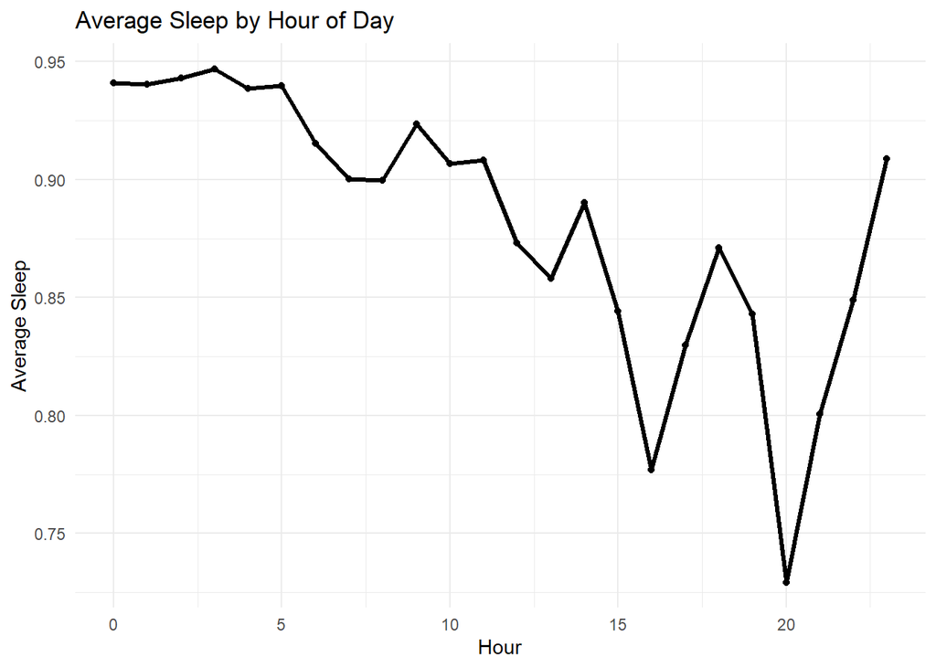

```r
# 1. Average Sleep
ggplot(hourly_summary_df, aes(x = hour_military, y = avg_sleep)) +
  geom_line(size = 1.2) +
  geom_point() +
  labs(title = "Average Sleep by Hour of Day", x = "Hour", y = "Average Sleep") +
  theme_minimal()
```

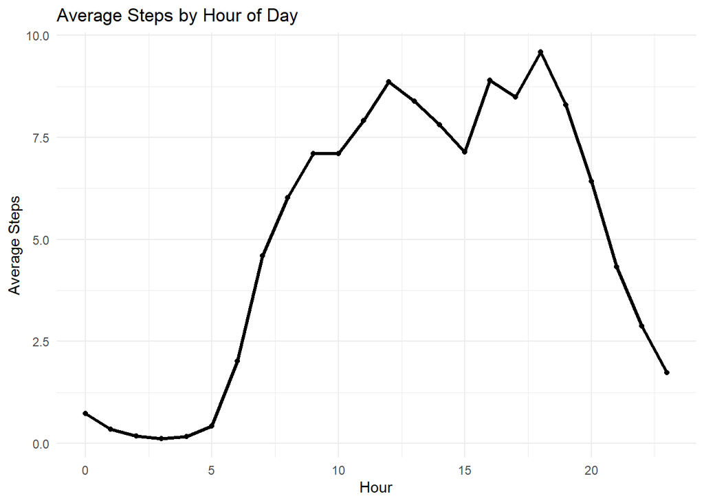

```r
# 2. Average Steps
ggplot(hourly_summary_df, aes(x = hour_military, y = avg_steps)) +
  geom_line(size = 1.2) +
  geom_point() +
  labs(title = "Average Steps by Hour of Day", x = "Hour", y = "Average Steps") +
  theme_minimal()
```

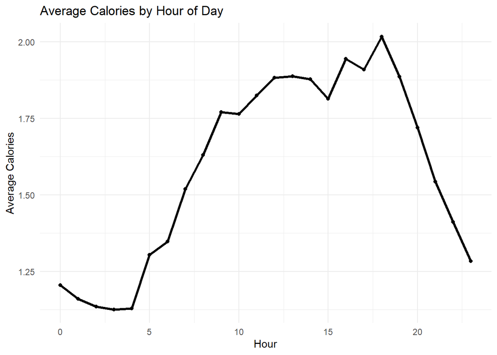

```r
# 3. Average Cals
ggplot(hourly_summary_df, aes(x = hour_military, y = avg_calories)) +
  geom_line(size = 1.2) +
  geom_point() +
  labs(title = "Average Calories by Hour of Day", x = "Hour", y = "Average Calories") +
  theme_minimal()
```

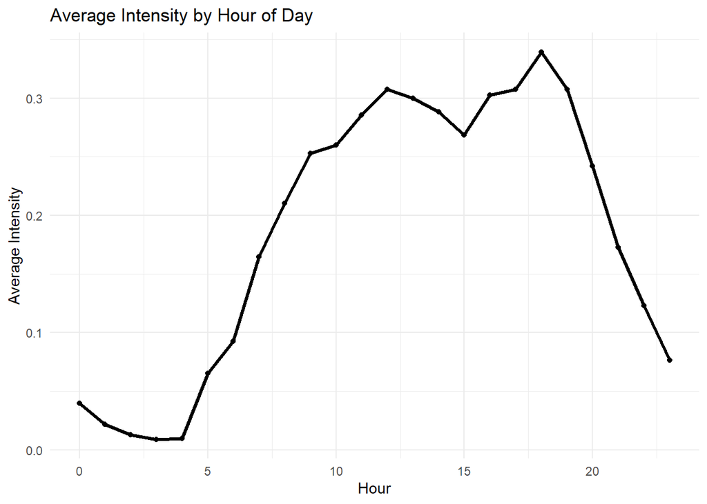

```r
# 4. Average Intensity
ggplot(hourly_summary_df, aes(x = hour_military, y = avg_intensity)) +
  geom_line(size = 1.2) +
  geom_point() +
  labs(title = "Average Intensity by Hour of Day", x = "Hour", y = "Average Intensity") +
  theme_minimal()
```

The first plot being, the average sleep per minute, for each hour of the day. As expected, we see a lower amount of sleep per minute during daylight hours, whereas that number goes up for nighttime.

The second plot is the average number of steps taken per minute, for each hour of the day. Once again, we see an expected result, where daylight hours end up being the most steps per minute, with a significant decline during nighttime hours. This trend continues for the next two plots as well. The first of which being average calories burned per minute, for each hour of the day. The second being the average intensity per minute, for each hour of the day. Both plots were consistent with the expectation of seeing higher values during daylight hours, and lower values at night. By looking at our visualizations, we inferred that some of our features are very strongly correlated, and decided to investigate this observation.

**Correlation Matrix:** After visualizing how individual features behave throughout the day, we determined that there could be some strong correlations between average steps, calories, and intensity. If this was the case, it would make sense to remove some of the redundant features, allowing us to reduce the dimensionality of our scoring function.

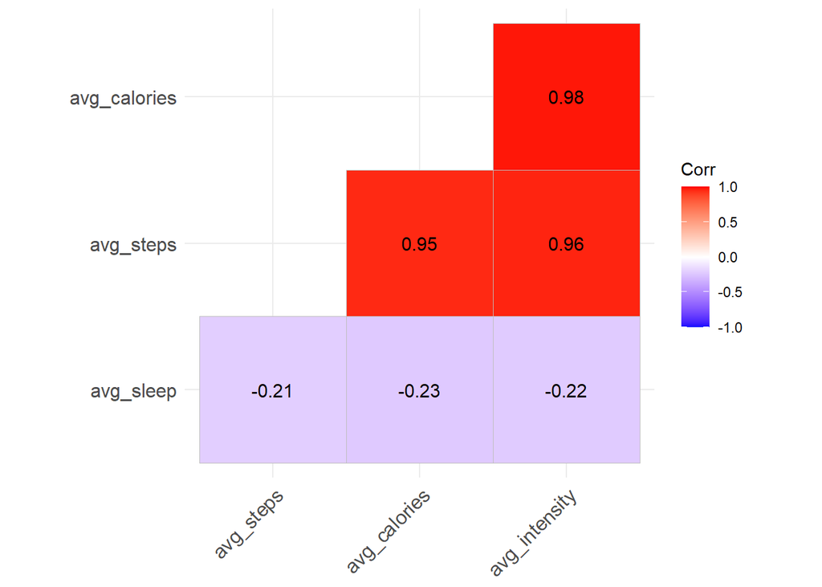

```r
correlation_matrix <- cor(intervals_df[, c("avg_steps", "avg_sleep", "avg_calories","avg_intensity")])
ggcorrplot(correlation_matrix, hc.order = TRUE, type = "lower", lab = TRUE)
```

After running the correlation matrix, our suspicions were confirmed. Average steps, calories, and intensity were all very strongly correlated to one another. Notably, sleep had a very weak correlation to any of the other features. To reduce the dimensionality, we decided to exclude steps and calories from our scoring function, as we felt that any one of the three strongly correlated features would be sufficient at representing activity level. At this point, we have identified our features of interest as average sleep and intensity.

```r
minutes_summary_df <- minutes_summary_df %>%
  mutate(
    norm_sleep = (avg_sleep - min(avg_sleep)) / (max(avg_sleep) - min(avg_sleep)),
    norm_intensity = (avg_intensity - min(avg_intensity)) / (max(avg_intensity) - min(avg_intensity))
  )

hourly_summary_df <- hourly_summary_df %>%
  mutate(
    norm_sleep = (avg_sleep - min(avg_sleep)) / (max(avg_sleep) - min(avg_sleep)),
    norm_intensity = (avg_intensity - min(avg_intensity)) / (max(avg_intensity) - min(avg_intensity))
  )
```

```r
weight_intensity <- 0.4
weight_sleep <- 0.6

minutes_summary_df <- minutes_summary_df %>%
  mutate(
    opportunity_score = weight_intensity*(1 - abs(norm_intensity - 0.5) * 2) + weight_sleep*(1 - norm_sleep)
  )

hourly_summary_df <- hourly_summary_df %>%
  mutate(
    opportunity_score = weight_intensity*(1 - abs(norm_intensity - 0.5) * 2) + weight_sleep*(1 - norm_sleep)
  )
```

**Break down of opportunity Score:** By identifying any lingering redundancies in our dataset, we were now able to create our scoring function with the features sleep and intensity.

Before creating our function, it was necessary to normalize—or scale—the features to support our scoring function. We found normalizing the data yielded better scores. After normalization our two new variables, norm_intensity, and norm_sleep represent the normalized datapoints for our intensity and sleep features.

Next, we created our scoring function, called opportunity score. The opportunity score formula is as follows:

opportunity_score = 0.4*(1 - |norm_intensity – 0.5| * 2) + 0.6*(1 - norm_sleep)

Inside the first set of parentheses, is a formula to reward values closer to the middle of the distribution. Originally, we created a formula that rewards low activity, however that would heavily favor nighttime hours, as individuals are likely to be sleeping. To combat this, we used this formula to ensure that moderate intensity is favored. If there is moderate intensity, we can be more confident that an individual is not sleeping during that time interval.

Inside the second set of parentheses, is the normalized value of sleep per datapoint, subtracted from the normalized maximum value of one. This allows the score to best reward low sleep values.

Each set of parameters are multiplied by a weight value. The weights were determined by how important we felt each feature was to the score based on our use-case. We decided to weigh sleep more heavily than intensity, as potential customers who are sleeping have no potential to view a marketing advertisement, whereas a woke but active individuals could still be exposed to these advertisements.

## Opportunity Score Results:

Displayed below are the summary and descriptive statistics of the newly derived feature opportunity score.

```r
summary(minutes_summary_df$opportunity_score)
```

```
##    Min. 1st Qu.  Median    Mean 3rd Qu.    Max.
## 0.00000 0.07461 0.20912 0.22986 0.34286 0.99121
```

```r
mean(minutes_summary_df$opportunity_score)
```

```
## [1] 0.22986
```

```r
sd(minutes_summary_df$opportunity_score)
```

```
## [1] 0.1746511
```

```r
var(minutes_summary_df$opportunity_score)
```

```
## [1] 0.03050302
```

```r
summary(hourly_summary_df$opportunity_score)
```

```
##    Min. 1st Qu.  Median    Mean 3rd Qu.    Max.
##  0.0000  0.1957  0.2857  0.3223  0.4458  0.8354
```

```r
mean(hourly_summary_df$opportunity_score)
```

```
## [1] 0.322257
```

```r
sd(hourly_summary_df$opportunity_score)
```

```
## [1] 0.2227607
```

```r
var(hourly_summary_df$opportunity_score)
```

```
## [1] 0.04962231
```

**Minute interval breakdown:** The mean is a score of 0.230, the standard deviation is 0.175, and the variance is 0.031. When looking at the summary statistics, the first and third quartiles appear to be relatively low. These early indications suggest that the distribution will be bottom heavy, where most scores are relatively low. Moreover, there is potential for a right skew. As we go on, this is something that we felt was necessary to investigate and account for.

```r
hourly_summary_df <- minutes_summary_df %>%
  group_by(hour_military) %>%
  summarize(opportunity_score = mean(opportunity_score, na.rm = TRUE),
            norm_intensity = mean(norm_intensity, na.rm = TRUE),
            norm_sleep = mean(norm_sleep, na.rm = TRUE)
            )
```

**Opportunity Level:** Our final step of setting up our opportunity scores, was to label each score as good, mid, or bad. We did this by creating bins for our scores, and then labeling each bin. By doing this, we hoped to be able to find that certain time slots cluster together into individual bins.

```r
minutes_summary_df <- minutes_summary_df %>%
  mutate(
    opportunity_level = cut(opportunity_score,
                            breaks = c(0, 1/3, 2/3, 1),
                            labels = c("bad", "mid", "good"),
                            include.lowest = TRUE)
  )

hourly_summary_df <- hourly_summary_df %>%
  mutate(
    opportunity_level = cut(opportunity_score,
                            breaks = quantile(opportunity_score, probs = c(0, 1/3, 2/3, 1), na.rm = TRUE),
                            labels = c("bad", "mid", "good"),
                            include.lowest = TRUE)
  )
```

**EDA of Opportunity Score and its Components** Understanding user behavior via sleep, intensity, and opportunity score metrics is crucial for optimizing advertising and engagement strategies. This EDA uses various boxplots, histograms, and statistical summaries to uncover trends in daily activity patters to help determine when users are most and least receptive to engagement.

## Boxplot of Opportunity Scores:

Below are boxplots of opportunity score, one an average of the 10-minute interval distribution, and the other a representation of an hourly distribution.

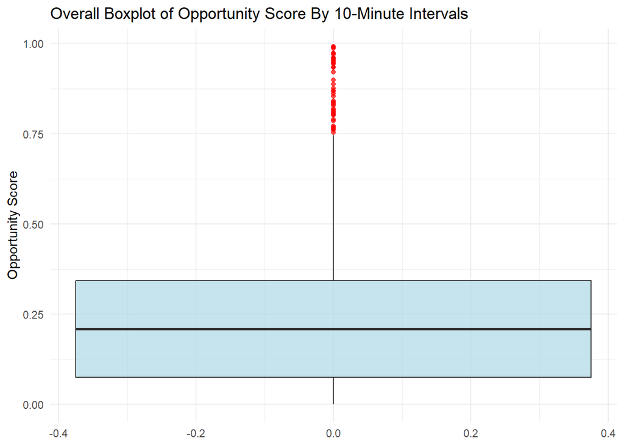

```r
# Average
ggplot(minutes_summary_df, aes(y = opportunity_score)) +
  geom_boxplot(fill = "lightblue", alpha = 0.7, outlier.color = "red") +
  labs(title = "Overall Boxplot of Opportunity Score By 10-Minute Intervals", y = "Opportunity Score") +
  theme_minimal()
```

```r
summary(intervals_df$opportunity_score)
```

```
## Length  Class   Mode
##      0   NULL   NULL
```

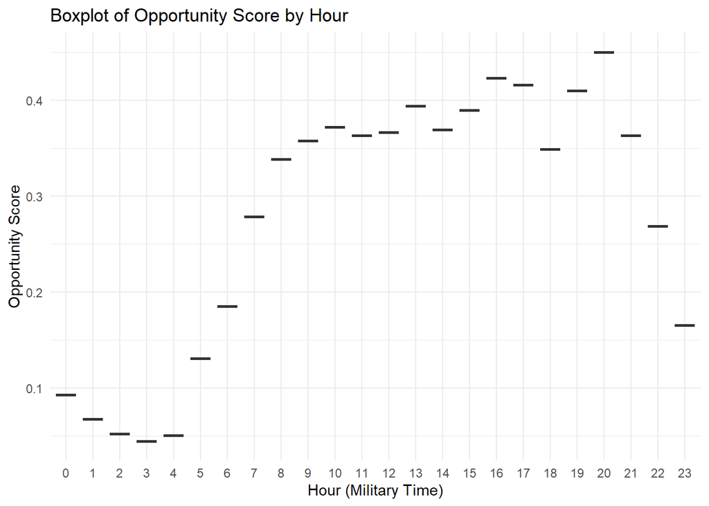

```r
# Hourly

ggplot(hourly_summary_df, aes(x = as.factor(hour_military), y = opportunity_score)) +
  geom_boxplot(fill = "lightblue", alpha = 0.7, outlier.color = "red") +
  labs(title = "Boxplot of Opportunity Score by Hour", x = "Hour (Military Time)", y = "Opportunity Score") +
  theme_minimal()
```

```r
tapply(hourly_summary_df$opportunity_score, hourly_summary_df$hour_military, summary)
```

```
## $`0`
##    Min. 1st Qu.  Median    Mean 3rd Qu.    Max.
## 0.09325 0.09325 0.09325 0.09325 0.09325 0.09325
##
## $`1`
##    Min. 1st Qu.  Median    Mean 3rd Qu.    Max.
## 0.06757 0.06757 0.06757 0.06757 0.06757 0.06757
##
## $`2`
##    Min. 1st Qu.  Median    Mean 3rd Qu.    Max.
## 0.05259 0.05259 0.05259 0.05259 0.05259 0.05259
##
## $`3`
##    Min. 1st Qu.  Median    Mean 3rd Qu.    Max.
## 0.04503 0.04503 0.04503 0.04503 0.04503 0.04503
##
## $`4`
##    Min. 1st Qu.  Median    Mean 3rd Qu.    Max.
## 0.05082 0.05082 0.05082 0.05082 0.05082 0.05082
##
## $`5`
##    Min. 1st Qu.  Median    Mean 3rd Qu.    Max.
##  0.1308  0.1308  0.1308  0.1308  0.1308  0.1308
##
## $`6`
##    Min. 1st Qu.  Median    Mean 3rd Qu.    Max.
##  0.1851  0.1851  0.1851  0.1851  0.1851  0.1851
##
## $`7`
##    Min. 1st Qu.  Median    Mean 3rd Qu.    Max.
##  0.2788  0.2788  0.2788  0.2788  0.2788  0.2788
##
## $`8`
##    Min. 1st Qu.  Median    Mean 3rd Qu.    Max.
##  0.3384  0.3384  0.3384  0.3384  0.3384  0.3384
##
## $`9`
##    Min. 1st Qu.  Median    Mean 3rd Qu.    Max.
##  0.3577  0.3577  0.3577  0.3577  0.3577  0.3577
##
```

[output cut: 40 more lines]

```
## $`20`
##    Min. 1st Qu.  Median    Mean 3rd Qu.    Max.
##    0.45    0.45    0.45    0.45    0.45    0.45
##
## $`21`
##    Min. 1st Qu.  Median    Mean 3rd Qu.    Max.
##  0.3633  0.3633  0.3633  0.3633  0.3633  0.3633
##
## $`22`
##    Min. 1st Qu.  Median    Mean 3rd Qu.    Max.
##  0.2685  0.2685  0.2685  0.2685  0.2685  0.2685
##
## $`23`
##    Min. 1st Qu.  Median    Mean 3rd Qu.    Max.
##  0.1658  0.1658  0.1658  0.1658  0.1658  0.1658
```

**Opportunity Score By 10-Minute Intervals:** This boxplot gives us a visual representation of the summary statistics of the 10-minute intervals. This boxplot is an indication that the distribution may be bottom heavy, and has potential for a right tail, as there are many outliers.

**Opportunity Score By Hourly Intervals:** This boxplot provides a visual representation of the distributions of the hourly intervals throughout the day. Based on the output, it seems that while this is good for showing the trends, it is not a very helpful indication of binned distributions.

## Boxplot of Intensity:

Below are boxplots of intensity, one an average of the 10-minute interval distribution, and the other a representation of an hourly distribution.

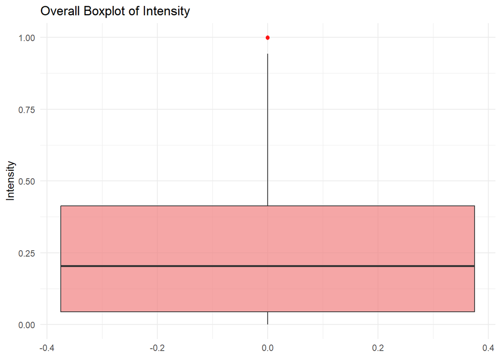

```r
# Average
ggplot(minutes_summary_df, aes(y = norm_intensity)) +
  geom_boxplot(fill = "lightcoral", alpha = 0.7, outlier.color = "red") +
  labs(title = "Overall Boxplot of Intensity", y = "Intensity") +
  theme_minimal()
```

```r
summary(minutes_summary_df$avg_intensity)
```

```
##    Min. 1st Qu.  Median    Mean 3rd Qu.    Max.
## 0.00000 0.02424 0.11250 0.13840 0.22812 0.55152
```

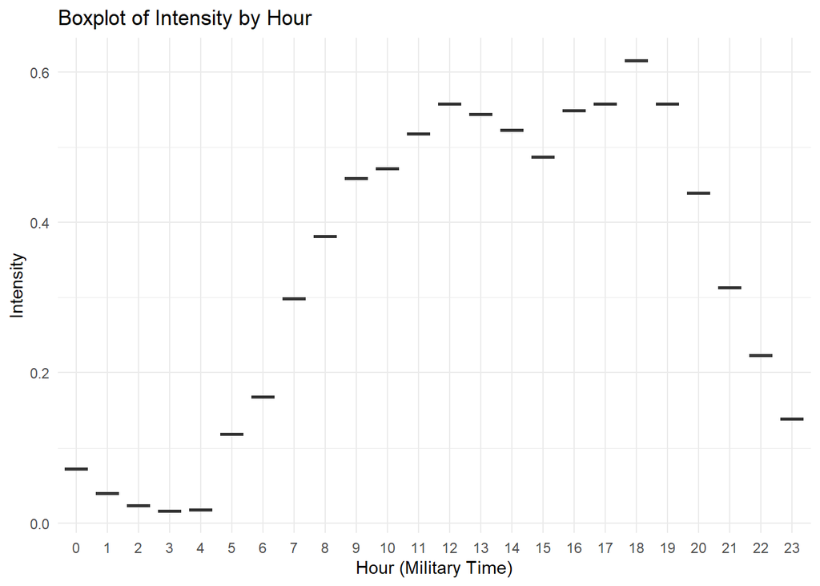

```r
# Hourly
ggplot(hourly_summary_df, aes(x = as.factor(hour_military), y = norm_intensity)) +
  geom_boxplot(fill = "lightcoral", alpha = 0.7, outlier.color = "red") +
  labs(title = "Boxplot of Intensity by Hour", x = "Hour (Military Time)", y = "Intensity") +
  theme_minimal()
```

```r
tapply(hourly_summary_df$norm_intensity, hourly_summary_df$hour_military, summary)
```

```
## $`0`
##    Min. 1st Qu.  Median    Mean 3rd Qu.    Max.
## 0.07225 0.07225 0.07225 0.07225 0.07225 0.07225
##
## $`1`
##    Min. 1st Qu.  Median    Mean 3rd Qu.    Max.
## 0.03986 0.03986 0.03986 0.03986 0.03986 0.03986
##
## $`2`
##    Min. 1st Qu.  Median    Mean 3rd Qu.    Max.
## 0.02305 0.02305 0.02305 0.02305 0.02305 0.02305
##
## $`3`
##    Min. 1st Qu.  Median    Mean 3rd Qu.    Max.
## 0.01653 0.01653 0.01653 0.01653 0.01653 0.01653
##
## $`4`
##    Min. 1st Qu.  Median    Mean 3rd Qu.    Max.
## 0.01745 0.01745 0.01745 0.01745 0.01745 0.01745
##
## $`5`
##    Min. 1st Qu.  Median    Mean 3rd Qu.    Max.
##  0.1183  0.1183  0.1183  0.1183  0.1183  0.1183
##
## $`6`
##    Min. 1st Qu.  Median    Mean 3rd Qu.    Max.
##  0.1681  0.1681  0.1681  0.1681  0.1681  0.1681
##
## $`7`
##    Min. 1st Qu.  Median    Mean 3rd Qu.    Max.
##  0.2985  0.2985  0.2985  0.2985  0.2985  0.2985
##
## $`8`
##    Min. 1st Qu.  Median    Mean 3rd Qu.    Max.
##  0.3814  0.3814  0.3814  0.3814  0.3814  0.3814
##
## $`9`
##    Min. 1st Qu.  Median    Mean 3rd Qu.    Max.
##  0.4586  0.4586  0.4586  0.4586  0.4586  0.4586
##
```

[output cut: 40 more lines]

```
## $`20`
##    Min. 1st Qu.  Median    Mean 3rd Qu.    Max.
##  0.4392  0.4392  0.4392  0.4392  0.4392  0.4392
##
## $`21`
##    Min. 1st Qu.  Median    Mean 3rd Qu.    Max.
##  0.3131  0.3131  0.3131  0.3131  0.3131  0.3131
##
## $`22`
##    Min. 1st Qu.  Median    Mean 3rd Qu.    Max.
##  0.2234  0.2234  0.2234  0.2234  0.2234  0.2234
##
## $`23`
##    Min. 1st Qu.  Median    Mean 3rd Qu.    Max.
##  0.1388  0.1388  0.1388  0.1388  0.1388  0.1388
```

## Boxplot of Sleep:

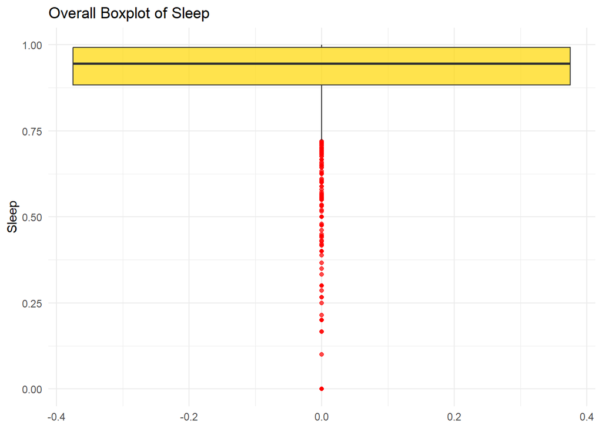

```r
# Average
ggplot(minutes_summary_df, aes(y = norm_sleep)) +
  geom_boxplot(fill = "gold", alpha = 0.7, outlier.color = "red") +
  labs(title = "Overall Boxplot of Sleep", y = "Sleep") +
  theme_minimal()
```

```r
summary(minutes_summary_df$avg_sleep)
```

```
##    Min. 1st Qu.  Median    Mean 3rd Qu.    Max.
##  0.0000  0.8841  0.9460  0.8998  0.9929  1.0000
```

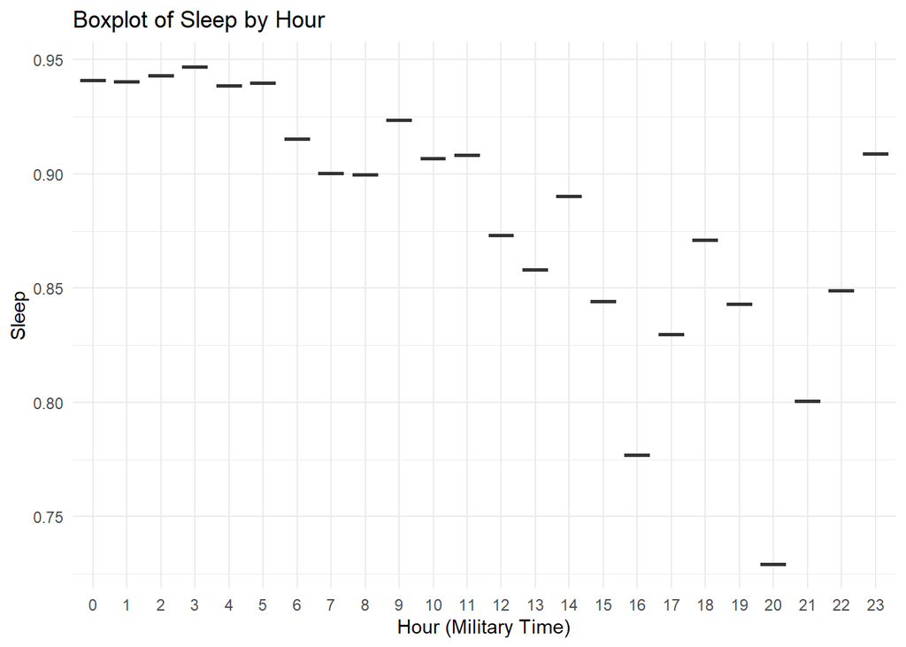

```r
# Hourly
ggplot(hourly_summary_df, aes(x = as.factor(hour_military), y = norm_sleep)) +
  geom_boxplot(fill = "gold", alpha = 0.7, outlier.color = "red") +
  labs(title = "Boxplot of Sleep by Hour", x = "Hour (Military Time)", y = "Sleep") +
  theme_minimal()
```

```r
tapply(hourly_summary_df$norm_sleep, hourly_summary_df$hour_military, summary)
```

```
## $`0`
##    Min. 1st Qu.  Median    Mean 3rd Qu.    Max.
##  0.9409  0.9409  0.9409  0.9409  0.9409  0.9409
##
## $`1`
##    Min. 1st Qu.  Median    Mean 3rd Qu.    Max.
##  0.9405  0.9405  0.9405  0.9405  0.9405  0.9405
##
## $`2`
##    Min. 1st Qu.  Median    Mean 3rd Qu.    Max.
##  0.9431  0.9431  0.9431  0.9431  0.9431  0.9431
##
## $`3`
##    Min. 1st Qu.  Median    Mean 3rd Qu.    Max.
##   0.947   0.947   0.947   0.947   0.947   0.947
##
## $`4`
##    Min. 1st Qu.  Median    Mean 3rd Qu.    Max.
##  0.9386  0.9386  0.9386  0.9386  0.9386  0.9386
##
## $`5`
##    Min. 1st Qu.  Median    Mean 3rd Qu.    Max.
##  0.9397  0.9397  0.9397  0.9397  0.9397  0.9397
##
## $`6`
##    Min. 1st Qu.  Median    Mean 3rd Qu.    Max.
##  0.9152  0.9152  0.9152  0.9152  0.9152  0.9152
##
## $`7`
##    Min. 1st Qu.  Median    Mean 3rd Qu.    Max.
##  0.9004  0.9004  0.9004  0.9004  0.9004  0.9004
##
## $`8`
##    Min. 1st Qu.  Median    Mean 3rd Qu.    Max.
##  0.8998  0.8998  0.8998  0.8998  0.8998  0.8998
##
## $`9`
##    Min. 1st Qu.  Median    Mean 3rd Qu.    Max.
##  0.9236  0.9236  0.9236  0.9236  0.9236  0.9236
##
```

[output cut: 40 more lines]

```
## $`20`
##    Min. 1st Qu.  Median    Mean 3rd Qu.    Max.
##  0.7293  0.7293  0.7293  0.7293  0.7293  0.7293
##
## $`21`
##    Min. 1st Qu.  Median    Mean 3rd Qu.    Max.
##  0.8005  0.8005  0.8005  0.8005  0.8005  0.8005
##
## $`22`
##    Min. 1st Qu.  Median    Mean 3rd Qu.    Max.
##  0.8491  0.8491  0.8491  0.8491  0.8491  0.8491
##
## $`23`
##    Min. 1st Qu.  Median    Mean 3rd Qu.    Max.
##  0.9088  0.9088  0.9088  0.9088  0.9088  0.9088
```

## Bar Graphs of Opportunity Score, Intensity, and Sleep

[figure not shown]

```r
# Mean opportunity score by time interval
ggplot(hourly_summary_df, aes(x = hour_military, y = opportunity_score)) +
  geom_col(fill = "darkorange") +
  labs(title = "Average Opportunity Score by 1 Minute Interval (Best Time for TV Ads)",
       x = "10 Minute Intervals (Military Time)",
       y = "Mean Opportunity Score") +
  theme(axis.text.x = element_blank())
```

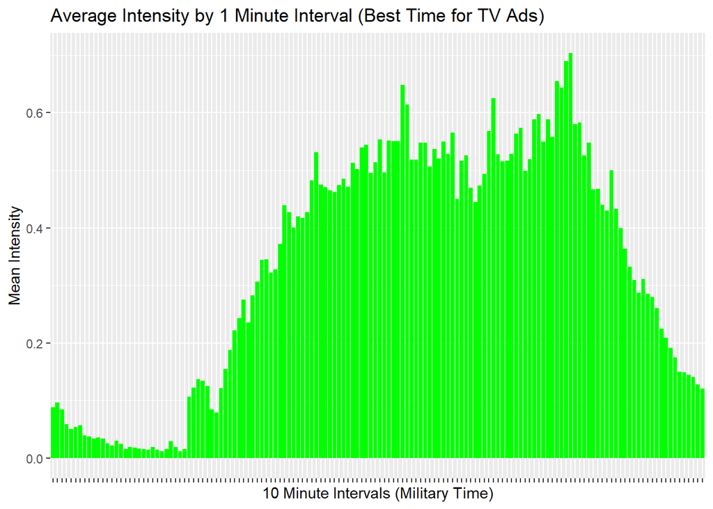

```r
intensity_summary <- minutes_summary_df %>%
  group_by(time_only) %>%
  summarize(norm_intensity = mean(norm_intensity, na.rm = TRUE))

# Mean intensity by time interval
ggplot(intensity_summary, aes(x = time_only, y = norm_intensity)) +
  geom_col(fill = "green") +
  labs(title = "Average Intensity by 1 Minute Interval (Best Time for TV Ads)",
       x = "10 Minute Intervals (Military Time)",
       y = "Mean Intensity") +
  theme(axis.text.x = element_blank())
```

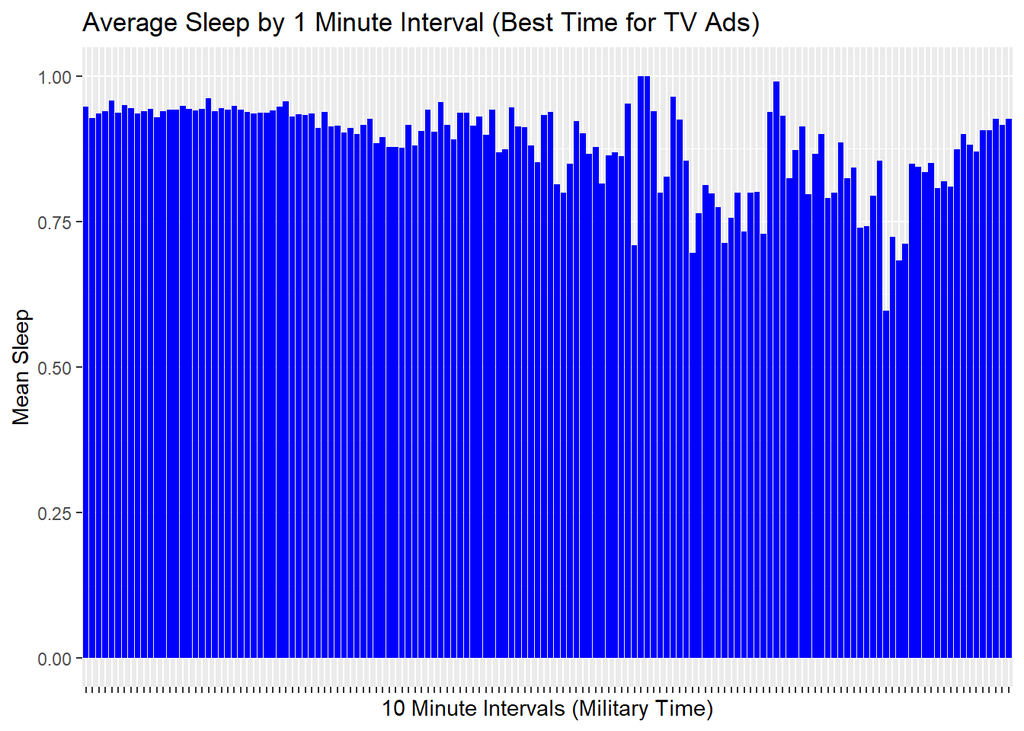

```r
sleep_summary <- minutes_summary_df %>%
  group_by(time_only) %>%
  summarize(norm_sleep = mean(norm_sleep, na.rm = TRUE))

# Mean sleep by time interval
ggplot(sleep_summary, aes(x = time_only, y = norm_sleep)) +
  geom_col(fill = "blue") +
  labs(title = "Average Sleep by 1 Minute Interval (Best Time for TV Ads)",
       x = "10 Minute Intervals (Military Time)",
       y = "Mean Sleep") +
  theme(axis.text.x = element_blank())
```

The intensity bar graph further supports earlier findings—activity increases in the morning, peaks in the late afternoon, and declines into the evening. The sleep graph reinforces the expected cycle, with the lowest sleep scores occurring in daylight hours and reaching near-max levels at night. However, it is worth noting that despite the correct trend, sleep averages seem unusually high. This could be an indication that there is some sort of sampling issue regarding the data. These visualizations provide a clear breakdown of the individual components that we used to calculate the opportunity score, offering insights into the best times for marketing engagement.

## QQ Plot Opportunity Score

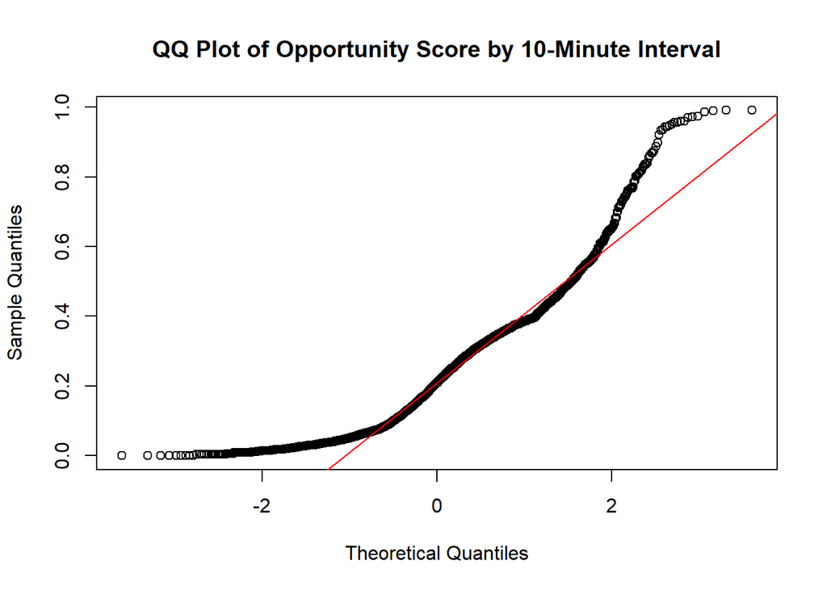

```r
qqnorm(minutes_summary_df$opportunity_score, main = "QQ Plot of Opportunity Score by 10-Minute Interval")
qqline(minutes_summary_df$opportunity_score, col = "red")
```

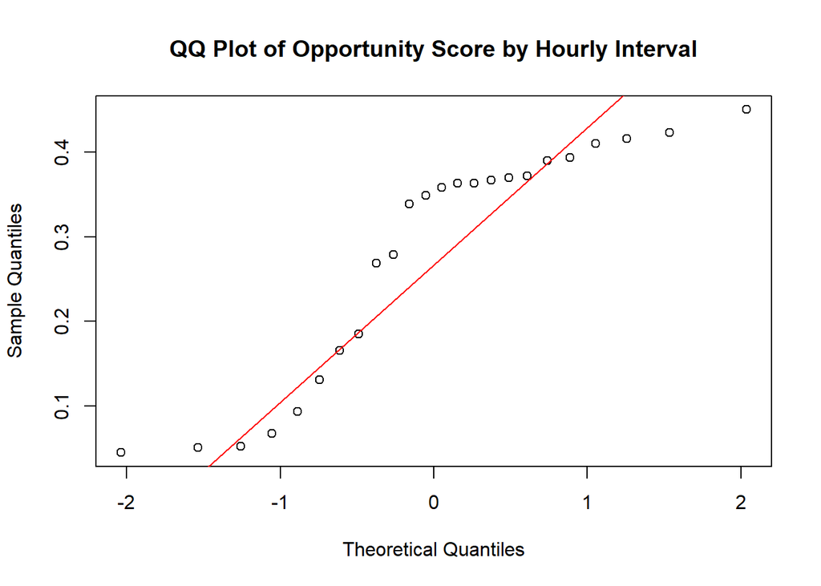

```r
qqnorm(hourly_summary_df$opportunity_score, main = "QQ Plot of Opportunity Score by Hourly Interval")
qqline(hourly_summary_df$opportunity_score, col = "red")
```

## QQ Plot Intensity

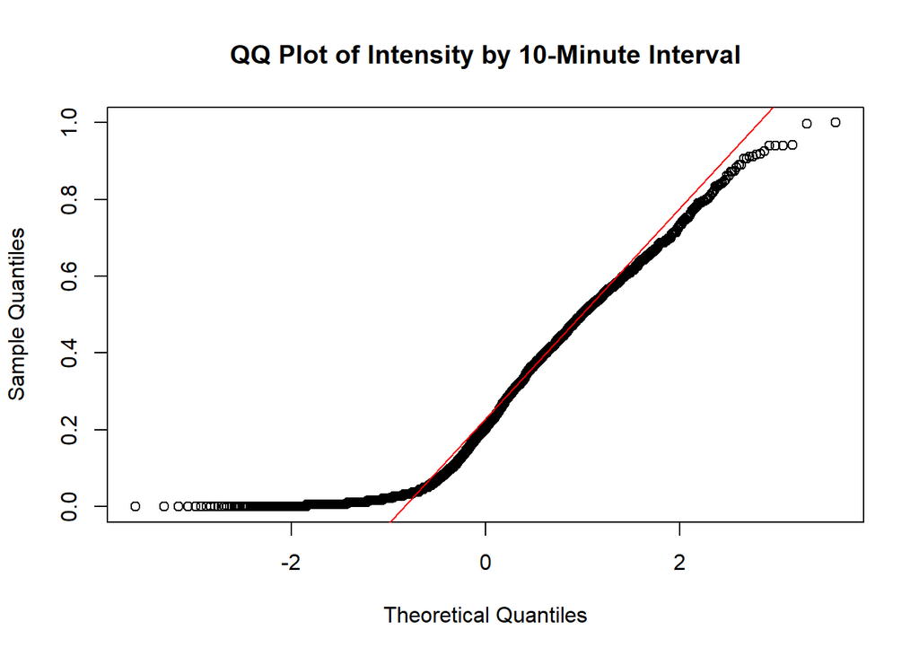

```r
qqnorm(minutes_summary_df$norm_intensity, main = "QQ Plot of Intensity by 10-Minute Interval")
qqline(minutes_summary_df$norm_intensity, col = "red")
```

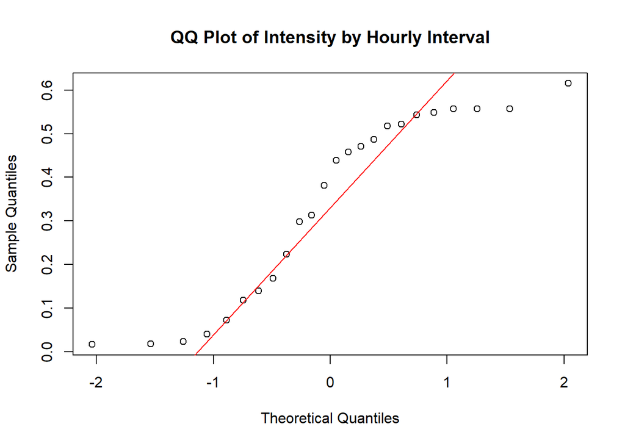

```r
qqnorm(hourly_summary_df$norm_intensity, main = "QQ Plot of Intensity by Hourly Interval")
qqline(hourly_summary_df$norm_intensity, col = "red")
```

## QQ Plot Sleep

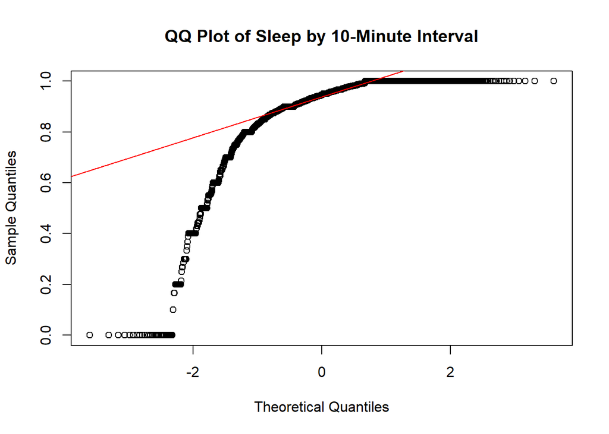

```r
qqnorm(minutes_summary_df$norm_sleep, main = "QQ Plot of Sleep by 10-Minute Interval")
qqline(minutes_summary_df$norm_sleep, col = "red")
```

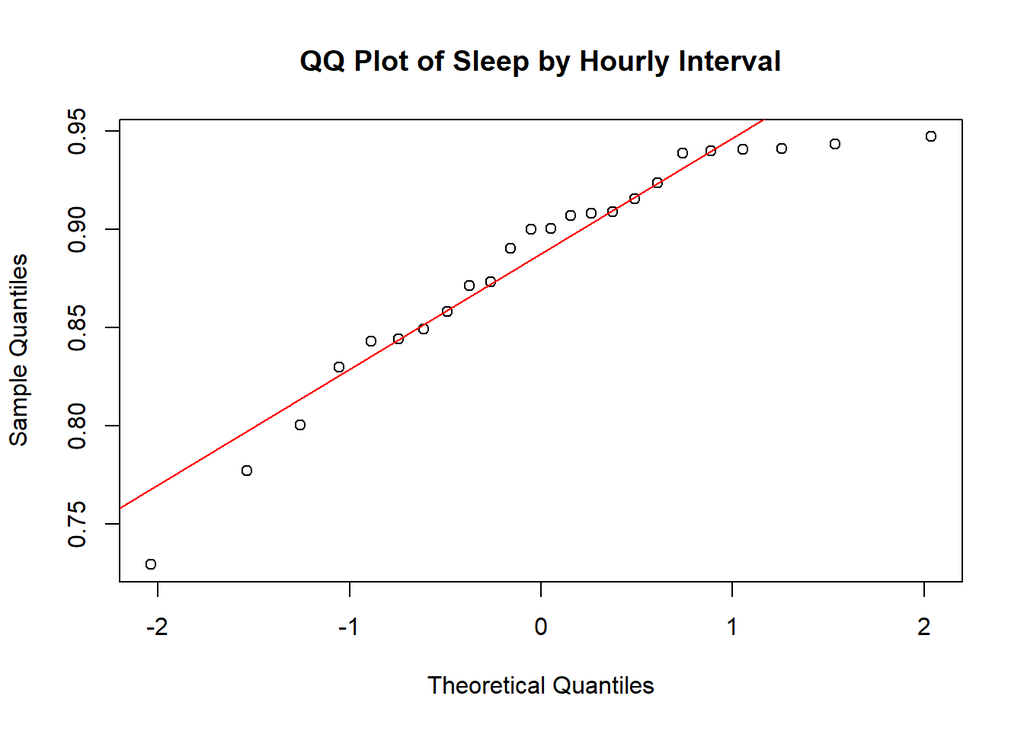

```r
qqnorm(hourly_summary_df$norm_sleep, , main = "QQ Plot of Sleep by Hourly Interval")
qqline(hourly_summary_df$norm_sleep, col = "red")
```

The Q-Q plots for opportunity score, intensity, and sleep confirm our suspicion that none of these variables are normally distributed. Instead, they exhibit significant skewness. For Opportunity Score, we are able to see a right skew, indicating that the average is on the lower end, and there are outliers on the higher end that draw the mean up. This aligns with our earlier findings that most time steps receive low scores, but a few receive high scores. The Q-Q plot for intensity shows a similar pattern, displaying a right skew. The Q-Q plot for sleep, while showing a skew, is done so in the opposite direction. This distribution indicates that most time steps receive high sleep scores, with some low scores pulling the mean down.

## Histogram Distribution Plot Opportunity Score

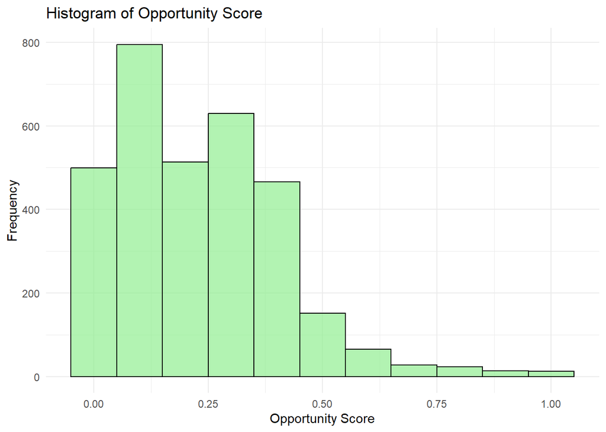

```r
ggplot(minutes_summary_df, aes(x = opportunity_score)) +
  geom_histogram(binwidth = 0.1, fill = "lightgreen", color = "black", alpha = 0.7) +
  labs(title = "Histogram of Opportunity Score", x = "Opportunity Score", y = "Frequency") +
  theme_minimal()
```

After seeing the QQ plots suggested a right skew, it was important for us to look into the distribution for a better visualization. For opportunity score, the histogram shows that most scores fall heavily on the left end of the distribution, with a tail on the right end. This indicates that there are a few time intervals that receive high scores, but the majority of intervals receive low scores. This aligns with our earlier observation that most time steps do not seem to be yield optimal opportunity scores.

## Histogram Intensity

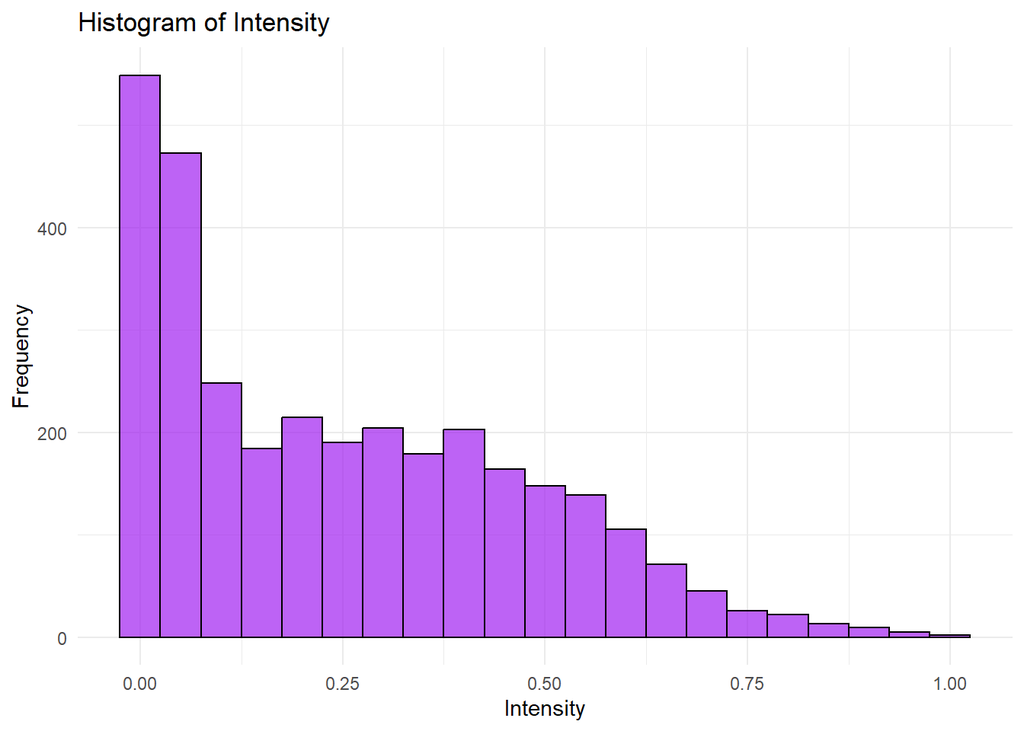

```r
ggplot(minutes_summary_df, aes(x = norm_intensity)) +
  geom_histogram(binwidth = 0.05, fill = "purple", color = "black", alpha = 0.7) +
  labs(title = "Histogram of Intensity", x = "Intensity", y = "Frequency") +
  theme_minimal()
```

## Histogram Sleep

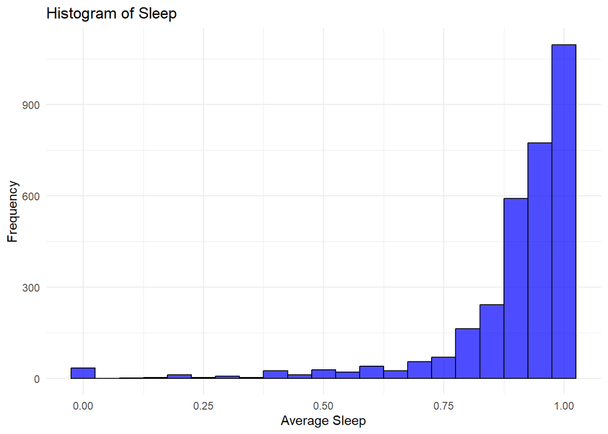

```r
ggplot(minutes_summary_df, aes(x = norm_sleep)) +
  geom_histogram(binwidth = 0.05, fill = "blue", color = "black", alpha = 0.7) +
  labs(title = "Histogram of Sleep", x = "Average Sleep", y = "Frequency") +
  theme_minimal()
```

The histograms of intensity and sleep provide further context to our exploratory analysis. The intensity histogram reveals a right-skewed distribution, where most recorded values are low, confirming that users spend a significant portion of their time in low-movement states. The sleep histogram, in contrast, shows a strong left-skew, where most sleep values are clustered near 1.0, suggesting that the majority of users receive high sleep scores, but a small subset experiences irregular or fragmented sleep. All of these histogram distributions accurately reflect the trends observed in the boxplots, bar graphs, and Q-Q plots. Additionally, we can see that generally, opportunity score and intensity follow the same trend, while sleep is appears to be inversely correlated with the other two features.

Upon completion of EDA, there were important takeaways that we had become aware of. First, our opportunity scores did not have a normalized distribution. This is important to be aware of, as this limits what type of analysis we can conduct. Second, the opportunity scores are right skewed, indicating that good scores are scarce, and bad scores are common. Third, opportunity score and intensity seem to be somewhat related, while sleep appears indirectly correlated to the other features. This is an interesting finding, as it is an indication of whether or not our scoring function makes logical sense.

# Statistical Analysis

Now that we have completed EDA, we can now move onto our statistical testing. Our Q-Q plots, along with our histogram distributions, made it clear to us that our data was not normalized. This caused us to have to eliminate any statistical tests that require a normal distribution, so we will be using non-parametric tests to analyze our data, namely the Kruskal-Wallis and Chi-Square tests.

The Kruskal-Wallis test will replace the ANOVA test, and will be used to determine if there is a significant difference in opportunity scores between different time intervals, both for our hourly and 10-minute interval breakdowns.

The Chi-Square test will be used to determine if there are significant differences in the distribution of good, mid, and bad opportunity scores across 10-minute intervals. This will help us determine wehther or not opportunity level is not randomly distributed across time.

## Kruskal Wallis Test: Opportunity Scores Across 10-Minute Time Intervals

Below is the result of our initial significance test, conducted under the following conditions: The *Null Hypothesis* posits that there is no variation in opportunity scores across different 10-minute intervals. Conversely, the *Alternative Hypothesis* suggests that there is a measurable difference in opportunity scores between these 10-minute intervals.

```r
kruskal.test(minutes_summary_df$opportunity_score ~ minutes_summary_df$time_only)
```

```
##
##  Kruskal-Wallis rank sum test
##
## data:  minutes_summary_df$opportunity_score by minutes_summary_df$time_only
## Kruskal-Wallis chi-squared = 2351.2, df = 143, p-value < 2.2e-16
```

The resulting p-value is less than 0.05, which allows us to reject the null hypothesis that the opportunity scores across all 10-minute time intervals are the same. Consequently, we accept the alternative hypothesis that there is a difference in opportunity scores across these 10-minute intervals. We will proceed with our analysis of the 10-minute intervals.

## Kruskal Wallis Test: Opportunity Scores Across 1-Hour Time Intervals

Below is the result of our initial significance test, conducted under the following conditions: The *Null Hypothesis* posits that there is no variation in opportunity scores across different 1 hour intervals. Conversely, the *Alternative Hypothesis* suggests that there is a measurable difference in opportunity scores between these 1 hour intervals.

```r
kruskal.test(hourly_summary_df$opportunity_score ~ hourly_summary_df$hour_military)
```

```
##
##  Kruskal-Wallis rank sum test
##
## data:  hourly_summary_df$opportunity_score by hourly_summary_df$hour_military
## Kruskal-Wallis chi-squared = 23, df = 23, p-value = 0.4608
```

The resulting p-value is greater than 0.05, indicating that we cannot reject the null hypothesis which states that the opportunity scores across all 1-hour time intervals are the same. Consequently, we cannot accept the alternative hypothesis suggesting a difference in opportunity scores across these intervals. This implies that analyzing time in smaller units, such as minutes, may provide better insights. Therefore, we will discontinue the deeper analysis of these 1-hour time intervals.

To understand these results better, we can look at which specific time periods have the biggest impact using our opportunity levels feature.

## Chi Square Test Conditions

Above we check to confirm that we can run the Chi Square test, as we must determine if each bin has at least 5 observations. Fortunately, the check confirms that we have more than 5 observations in each bin, so we can continue with our chi square test.

```r
# check for chi square assumptions in 10 minute intervals
nrow(minutes_summary_df %>% filter(opportunity_level == "good"))
```

```
## [1] 68
```

```r
nrow(minutes_summary_df %>% filter(opportunity_level == "mid"))
```

```
## [1] 805
```

```r
nrow(minutes_summary_df %>% filter(opportunity_level == "bad"))
```

```
## [1] 2321
```

Looking at the individual bins, it is interesting to note, that similar to what we observed in our EDA above, there are far more bad opportunity scores than good or mid. This is an important observation to take note of, as it is an indication that our bins accurately reflect the distribution of opportunity scores.

## Chi Square Test: Opportunity Level By 10 Minute Intervals

Below we run our Chi Square test on our opportunity level bins by 10-minute intervals. The goal is to determine if there is a significant difference between our bins. Our conditions are as follows: the Null Hypothesis states that there is no association between time and opportunity level The Alternative Hypothesis posits that there is an association between time and opportunity level

```r
chisq.test(minutes_summary_df$time_only, minutes_summary_df$opportunity_level)
```

```
##
##  Pearson's Chi-squared test
##
## data:  minutes_summary_df$time_only and minutes_summary_df$opportunity_level
## X-squared = 1587.6, df = 286, p-value < 2.2e-16
```

The resulting p-value is less than 0.05, so we reject the null hypothesis that there is no association between opportunity level and time, while accepting the alternative hypothesis that there is an association between opportunity level and time. We can now confidently say that opportunity scores, and hence their levels, are not randomly distributed across time intervals, and that there are in fact times of the day that yield better opportunity scores than others.

Moreover, further analysis could help identify which specific time periods have the most impact. Now that it is confirmed that each opportunity level does not exist due to chance, we can make recommendations for marketing hours based on our opportunity levels.

## Good Opportunity Levels

The table below displays the frequencies of the hours of the day that appear in the good opportunity level bin.

```r
table(minutes_summary_df$hour_military[minutes_summary_df$opportunity_level == "good"])
```

```
##
##  8  9 10 11 12 13 14 15 16 17 19 20 21
##  2  1  6  4  6  4  3  3  6  4  5 13 11
```

Our findings indicate that the most frequent high opportunity scores are between the hours of 20:00 and 22:00 (8 PM - 10 PM). This is a good indication that these time slots are the best for marketing advertisements, as individuals are awake but not too active. This is a good time to reach out to potential customers, as they are likely to be receptive to be most available.

# Conclusions

In this study, we wanted to figure out the best times to show marketing ads based on when people are most likely to be available. We defined this availability as when individuals are awake but resting. To test this, we used Fitbit data from 35 participants over a 1 month span, looking at their sleep patterns and activity levels.

Through our analysis, we found that people are more active during the day and less active at night. We created a score that helped us understand the best times to show ads, hoping to find the optimal time when individuals are inactive but also awake. We gave more importance to sleep, by weighing it more heavily since an individual who is sleeping has no chance to be effected by a marketing advertisement, while someone who is only lightly active might still pay attention.

After running statistical tests, we concluded that based on opportunity scores it is best to advertise between the hours of 8:00 PM and 10:00 PM. Interestingly, we found that most time slots had lower scores, emphasizing the importance of marketing at opportune times of day.

In future studies, we hope to expand our research to include more variables. One idea to improve our study could be adding more participants, allowing us to use independent data rather than averages. Another idea could be to determine what days would be best for marketing, as weekends are likely to yield different results than weekdays. Additionally, accounting for demographic data might help for targeting specific audiences. Ideal audiences for products vary by individual groups, so accounting for such differences could improve product outreach. Finally, we could collect data over the course of a longer period in order to look at seasonal patterns to determine the best time of year for marketing, as winter and summer likely yield different results.

In conclusion, our study shows that there are significant differences in marketing opportunity throughout the day. By understanding these patterns, businesses can better plan their marketing efforts to reach the largest possible audience.

## References

- Fitbit Data. (n.d.). *Kaggle*. Retrieved from https://www.kaggle.com/arashnic/fitbit